# Why people wash meat (or don't)

```python
                          'If you do commonly wash any raw meat before cooking, what are you trying to remove? Rank the following concerns in order of their importance to you, with #1 being the most important, #2 the next most important, and so on. If something isn’t a concern to you, leave the box blank. (You may only choose one row per ranking column.) [Slime]' : 'do_rank2_slime',
                          'If you do commonly wash any raw meat before cooking, what are you trying to remove? Rank the following concerns in order of their importance to you, with #1 being the most important, #2 the next most important, and so on. If something isn’t a concern to you, leave the box blank. (You may only choose one row per ranking column.) [Fat]' : 'do_rank2_fat',
                          'If you do commonly wash any raw meat before cooking, what are you trying to remove? Rank the following concerns in order of their importance to you, with #1 being the most important, #2 the next most important, and so on. If something isn’t a concern to you, leave the box blank. (You may only choose one row per ranking column.) [Meat juice (the pink, non-blood liquid that comes out of muscle tissue)]' : 'do_rank2_meat_juice',
                          'If you do commonly wash any raw meat before cooking, what are you trying to remove? Rank the following concerns in order of their importance to you, with #1 being the most important, #2 the next most important, and so on. If something isn’t a concern to you, leave the box blank. (You may only choose one row per ranking column.) [Other]' : 'do_rank2_other',
                          'If you said "other," please explain..3' : 'do_rank2_other_comments',
                          'If you do commonly wash any raw meat before cooking, please rank the methods you use, with #1 being the method you use most often, #2 next most often, and so on. If you don’t use the method at all, leave the box blank. (You may only choose one row per ranking column.) [Rinsing under running water]' : 'do_rank3_running_water',
                          'If you do commonly wash any raw meat before cooking, please rank the methods you use, with #1 being the method you use most often, #2 next most often, and so on. If you don’t use the method at all, leave the box blank. (You may only choose one row per ranking column.) [Rinsing in a bowl or basin of plain water]' : 'do_rank3_bowl_water',
                          'If you do commonly wash any raw meat before cooking, please rank the methods you use, with #1 being the method you use most often, #2 next most often, and so on. If you don’t use the method at all, leave the box blank. (You may only choose one row per ranking column.) [Rinsing in anything other than plain water (salt brine, vinegar, citrus, etc.)]' : 'do_rank3_bowl_not_water',
                          'If you do commonly wash any raw meat before cooking, please rank the methods you use, with #1 being the method you use most often, #2 next most often, and so on. If you don’t use the method at all, leave the box blank. (You may only choose one row per ranking column.) [Soaking awhile in plain water]' : 'do_rank3_soaking_water',
                          'If you do commonly wash any raw meat before cooking, please rank the methods you use, with #1 being the method you use most often, #2 next most often, and so on. If you don’t use the method at all, leave the box blank. (You may only choose one row per ranking column.) [Soaking awhile in anything other than plain water (salt brine, vinegar, citrus, etc.)]' : 'do_rank3_soaking_notwater',
                          'If you do commonly wash any raw meat before cooking, please rank the methods you use, with #1 being the method you use most often, #2 next most often, and so on. If you don’t use the method at all, leave the box blank. (You may only choose one row per ranking column.) [Other]' : 'do_rank3_other',
                          'If you said "other," please explain..4' : 'do_rank3_other_commments',
                          'If you commonly rinse or soak meat before cooking, you most-often use:' : 'commonly_rinse_with',
                          'If you commonly soak raw meat before cooking, please indicate how long.' : 'soak_time',
                          'If you do commonly rinse or soak raw meat in anything other than plain water, which of these things do you use? Check as many as apply.' : 'soak_rinse_in',
                          'If you do commonly wash any raw meat before cooking, how do you clean up afterward? Check any that apply to you.' : 'cleanup',
                          "When you eat at someone's house, how important is it to you that they be attentive to food safety in their food preparation?" : 'visitor_home_safety',
                          'When you eat at a commercial eatery, how important is it to you that they be attentive to food safety in their food preparation?': 'commercial_safety',
                          'Is there anything else you wish to share about your food preparation practices?' : 'comments_food_prep',
                          'Are there comments about consumer food safety education or food guidelines that you wish to share? ' : 'comments_food_safety_edu'

                                     }, inplace=True)
```

```python
# confirm changes to column headers
df_survey.info()
```

```
<class 'pandas.core.frame.DataFrame'>
RangeIndex: 13528 entries, 0 to 13527
Data columns (total 68 columns):
 #   Column                          Non-Null Count  Dtype
---  ------                          --------------  -----
 0   timestamp                       13528 non-null  object
 1   prepare_meat                    13528 non-null  object
 2   age                             13195 non-null  object
 3   gender                          13172 non-null  object
 4   country_origin                  13195 non-null  object
 5   country_residency               13195 non-null  object
 6   us_state_residency              6356 non-null   object
 7   race                            6356 non-null   object
 8   hispanic                        6356 non-null   object
 9   times_prepare_meal              13195 non-null  object
```

[output cut: 60 more lines]

```python
# display a full survey as sample to explore
# provide perspective on the possible types of responses for each question in the survey
pd.set_option("display.max_rows", None, "display.max_columns",None)
display(df_survey.iloc[99])
```

```
timestamp                                                             9/28/20 14:23
prepare_meat                                                                  Often
age                                                                              19
gender                                                                         Male
country_origin                                                               Canada
country_residency                                                            Canada
us_state_residency                                                              NaN
race                                                                            NaN
hispanic                                                                        NaN
times_prepare_meal                                                            Often
household_size                                                                    2
importance_food_safety_cooking                                                    4
follow_when_cooking               Wash my hands with soap and water, Wash cuttin...
often_wash_hands                                                   Most of the time
often_different_plates                                                      Usually
often_thermometer                                                           Usually
often_not_wash_utensils                                                       Never
often_not_wash_cutting_board                                                  Never
often_leave_food_2hrs                                                     Sometimes
wash_pork                                                                 Dont Wash
wash_poultry                                                              Dont Wash
wash_beef                                                                 Dont Wash
wash_lamb_goat                                                            Dont Wash
wash_fish                                                                 Dont Wash
wash_ground_meat                                                          Dont Wash
wash_other                                                                Dont Wash
wash_other_comments                                                             NaN
donot_rank_should                                                                 4
donot_rank_clean_enough                                                           3
donot_rank_warn_against                                                           1
donot_rank_preserve                                                               2
donot_rank_cultural                                                               5
donot_rank_other                                                                  6
donot_rank_other_comments                                                       NaN
do_rank_health                                                                  NaN
do_rank_religious                                                               NaN
do_rank_nonreligious                                                            NaN
do_rank_taste                                                                   NaN
do_rank_texture                                                                 NaN
do_rank_appearance                                                              NaN
```

[output cut: 14 more lines]

```
do_rank3_bowl_not_water                                                         NaN
do_rank3_soaking_water                                                          NaN
do_rank3_soaking_notwater                                                       NaN
do_rank3_other                                                                  NaN
do_rank3_other_commments                                                        NaN
commonly_rinse_with                                                             NaN
soak_time                                                                       NaN
soak_rinse_in                                                                   NaN
cleanup                                                                         NaN
visitor_home_safety                                                               4
commercial_safety                                                                 5
comments_food_prep                                                              NaN
comments_food_safety_edu                                                        NaN
Unnamed: 67                                                                     NaN
Name: 99, dtype: object
```

**Tidiness Issue #2:** Row 0 of data contains attempt of shorter column titles in the original dataset. SOLUTION: Since the columns have been renamed and shorten. Row 0 can be removed/dropped.

```python
# remove row with alternative, short titles
# reset index numbering
df_survey.drop(df_survey.index[0], inplace=True)
df_survey = df_survey.reset_index(drop=True)

# verify changes
df_survey.head(3)
```

|  | timestamp | prepare_meat | age | gender | country_origin | country_residency | us_state_residency | race | hispanic | times_prepare_meal | household_size | importance_food_safety_cooking | follow_when_cooking | often_wash_hands | often_different_plates | often_thermometer | often_not_wash_utensils | often_not_wash_cutting_board | often_leave_food_2hrs | wash_pork | wash_poultry | wash_beef | wash_lamb_goat | wash_fish | wash_ground_meat | wash_other | wash_other_comments | donot_rank_should | donot_rank_clean_enough | … |
| --- | --- | --- | --- | --- | --- | --- | --- | --- | --- | --- | --- | --- | --- | --- | --- | --- | --- | --- | --- | --- | --- | --- | --- | --- | --- | --- | --- | --- | --- | --- |
| 0 | 9/27/20 21:15 | Often | 22 | Male | Anguilla | United States of America | Alaska | White | No | Often | 12 | 3 | Wash my hands with soap and water, Separate ra... | All of the time (that is without fail) | Always | Usually | Always | Always | Always | Wash | Wash | Wash | Wash | Wash | Wash | Wash | NaN | 1 | 2 | … |
| 1 | 9/27/20 21:18 | Sometimes | 49 | Non-binary | United States of America | United States of America | Florida | Asian | Yes | Often | 7 | 2 | Wash my hands with soap and water, Wash cuttin... | Never | Always | Seldom | Seldom | Seldom | About Half the time | Dont Wash | Dont Wash | Dont Wash | Dont Wash | Dont Wash | Dont Wash | NaN | NaN | NaN | 1 | … |
| 2 | 9/28/20 14:11 | Sometimes | 32 | Male | United States of America | United States of America | Virginia | White | No | Sometimes | 1 | 4 | Wash my hands with soap and water, Wash cuttin... | Some of the time | Usually | Usually | Usually | Seldom | About Half the time | Dont Wash | Dont Wash | Dont Wash | Dont Wash | Dont Wash | Dont Wash | Dont Wash | NaN | NaN | NaN | … |

**Quality Issue #1:** Datatypes for timestamp is in object. SOLUTION: `timestamp` dtype converted to datetime.

```python
# change datatype of 'timestamp' to DateTime
df_survey['timestamp'] = pd.to_datetime(df_survey['timestamp'])

# confirm changes
df_survey['timestamp'].dtype
```

```
dtype('<M8[ns]')
```

**Quality Issue #2:** Datatype for `household_size` is in object and may contain fractional values. SOLUTION: `household_size` dtype converted to int.

```python
# unique values for 'household_size'
df_survey['household_size'].unique()
```

```
array(['12', '7', '1', '4', '2', nan, '3', '6', '5', '8', '10', '9',
       '2.5', '69', '0', '11', '15', '20', '27', '16', '380', '22', '3.5',
       '2.75', '1.5', '1.11E+15', '14', '33', 4.0, 3.0, 1.0, 2.0, 5.0,
       7.0, 6.0, 8.0, 16.0, 10.0, 9.0, 83.0, 12.0, 68.9, 11.0, 15.0, 1.5],
      dtype=object)
```

```python
# change '1.11E+15' to NaN
df_survey.loc[df_survey['household_size'] == "1.11E+15", 'household_size'] = np.nan

# convert dtype to float
df_survey['household_size'] = df_survey['household_size'].astype(float)
df_survey['household_size'].unique()
```

```
array([ 12.  ,   7.  ,   1.  ,   4.  ,   2.  ,    nan,   3.  ,   6.  ,
         5.  ,   8.  ,  10.  ,   9.  ,   2.5 ,  69.  ,   0.  ,  11.  ,
        15.  ,  20.  ,  27.  ,  16.  , 380.  ,  22.  ,   3.5 ,   2.75,
         1.5 ,  14.  ,  33.  ,  83.  ,  68.9 ])
```

```python
# change datatype of 'household_size' to int
# NaN entries for age are converted to <NA>
df_survey['household_size'] = pd.array(df_survey['household_size'].values).astype(int)

# confirm change
df_survey['household_size'].dtype
```

```
dtype('int64')
```

**Quality Issue #3:** Datatype for `age` is in object and may contain fractional values. SOLUTION: `age` dtype converted to int.

```python
df_survey['age'].unique()
```

```
array(['22', '49', '32', '30', '20', '26', '24', '16', nan, '18', '25',
       '35', '23', '19', '31', '29', '28', '21', '27', '41', '36', '50',
       '37', '39', '14', '42', '69', '15', '52', '46', '67', '17', '33',
       '34', '38', '43', '56', '13', '64', '12', '63', '51', '11', '45',
       '40', '55', '53', '62', '47', '68', '44', '66', '48', '60', '59',
       '61', '54', '57', '58', '72', '70', '568', '71', '73', '77', '1',
       '89', '65', 35.0, 33.0, 40.0, 41.0, 43.0, 22.0, 17.0, 34.0, 29.0,
       24.0, 23.0, 47.0, 26.0, 31.0, 20.0, 27.0, 57.0, 38.0, 28.0, 32.0,
       19.0, 37.0, 61.0, 15.0, 59.0, 16.0, 25.0, 18.0, 21.0, 44.0, 39.0,
       14.0, 42.0, 36.0, 65.0, 30.0, 74.0, 54.0, 50.0, 52.0, 56.0, 13.0,
       46.0, 53.0, 6.760000000000001e+47, 58.0, 67.0, 55.0, 45.0, 63.0,
       222.0, 71.0, 51.0, 49.0, 69.0, 60.0, 12.0, 11.0, 62.0, 78.0, 68.0,
       70.0, 79.0, 48.0, 77.0, 66.0, 10.0, 73.0, 64.0, 999.0, 72.0,
       1111111111.0], dtype=object)
```

```python
# change extreme values to NaN
df_survey.loc[df_survey['age'] == 6.760000000000001e+47, 'age'] = np.nan
df_survey.loc[df_survey['age'] == 1111111111.0, 'age'] = np.nan

# convert dtype to float
df_survey['age'] = df_survey['age'].astype(float)
df_survey['age'].unique()
```

```
array([ 22.,  49.,  32.,  30.,  20.,  26.,  24.,  16.,  nan,  18.,  25.,
        35.,  23.,  19.,  31.,  29.,  28.,  21.,  27.,  41.,  36.,  50.,
        37.,  39.,  14.,  42.,  69.,  15.,  52.,  46.,  67.,  17.,  33.,
        34.,  38.,  43.,  56.,  13.,  64.,  12.,  63.,  51.,  11.,  45.,
        40.,  55.,  53.,  62.,  47.,  68.,  44.,  66.,  48.,  60.,  59.,
        61.,  54.,  57.,  58.,  72.,  70., 568.,  71.,  73.,  77.,   1.,
        89.,  65.,  74., 222.,  78.,  79.,  10., 999.])
```

```python
# change datatype of 'age' to int
# NaN entries for age are converted to <NA>
df_survey['age'] = pd.array(df_survey['age'].values).astype(int)

# confirm type is now Int64
df_survey['age'].dtype
```

```
dtype('int64')
```

```python
# confirm datatype
df_survey.info()
```

```
<class 'pandas.core.frame.DataFrame'>
RangeIndex: 13527 entries, 0 to 13526
Data columns (total 68 columns):
 #   Column                          Non-Null Count  Dtype
---  ------                          --------------  -----
 0   timestamp                       13527 non-null  datetime64[ns]
 1   prepare_meat                    13527 non-null  object
 2   age                             13527 non-null  int64
 3   gender                          13171 non-null  object
 4   country_origin                  13194 non-null  object
 5   country_residency               13194 non-null  object
 6   us_state_residency              6355 non-null   object
 7   race                            6355 non-null   object
 8   hispanic                        6355 non-null   object
 9   times_prepare_meal              13194 non-null  object
```

[output cut: 60 more lines]

```python
df_survey['age'].value_counts()
```

```
 23                     912
 22                     874
 24                     855
 21                     815
 25                     797
 20                     795
 26                     667
 27                     625
 19                     606
 18                     573
 28                     548
 29                     506
 30                     459
 31                     373
 32                     370
```

[output cut: 60 more lines]

```python
# replace with NaN
df_survey.loc[df_survey['age'] == -9223372036854775808, 'age'] = np.nan

# confirm replacement
df_survey['age'].value_counts()
```

```
23.0     912
22.0     874
24.0     855
21.0     815
25.0     797
20.0     795
26.0     667
27.0     625
19.0     606
18.0     573
28.0     548
29.0     506
30.0     459
31.0     373
32.0     370
17.0     359
16.0     308
33.0     264
34.0     251
35.0     242
15.0     187
37.0     183
36.0     181
38.0     150
39.0     126
40.0     125
14.0     105
41.0      71
42.0      70
43.0      61
50.0      60
45.0      60
44.0      59
13.0      56
46.0      49
47.0      41
52.0      38
49.0      35
51.0      31
55.0      26
```

[output cut: 19 more lines]

```
71.0       4
65.0       4
11.0       4
73.0       3
77.0       3
999.0      1
89.0       1
79.0       1
1.0        1
10.0       1
74.0       1
222.0      1
78.0       1
568.0      1
Name: age, dtype: int64
```

```python
# rows before
print(len(df_survey))

# drop rows where age is less than 13 - parental permission not on record
df_survey.drop(df_survey[(df_survey.age<13)].index, inplace=True)

# replace entry with NaN rows where age is greater than 99
df_survey.loc[df_survey['age'] > 99, 'age'] = np.nan

# rows after
print(len(df_survey))

# verify changes
df_survey['age'].value_counts()
```

```
13527
13509
```

```
23.0    912
22.0    874
24.0    855
21.0    815
25.0    797
20.0    795
26.0    667
27.0    625
19.0    606
18.0    573
28.0    548
29.0    506
30.0    459
31.0    373
32.0    370
17.0    359
16.0    308
33.0    264
34.0    251
35.0    242
15.0    187
37.0    183
36.0    181
38.0    150
39.0    126
40.0    125
14.0    105
41.0     71
42.0     70
43.0     61
50.0     60
45.0     60
44.0     59
13.0     56
46.0     49
47.0     41
52.0     38
49.0     35
51.0     31
48.0     26
```

[output cut: 12 more lines]

```
70.0      8
63.0      8
64.0      8
67.0      7
69.0      5
72.0      5
71.0      4
65.0      4
73.0      3
77.0      3
78.0      1
79.0      1
89.0      1
74.0      1
Name: age, dtype: int64
```

**Quality Issue #5:** Gender field contain invalid entries. SOLUTION: The responses for gender will be catorgozied as: 'Male', 'Female', 'Non-binary', 'Prefer not to disclose' (all of which are choices) OR 'Other' which all other responses will be classified under.

```python
df_survey['gender'].value_counts()
```

```
Male                                                                                                                                                                                     11051
Female                                                                                                                                                                                    1636
Non-binary                                                                                                                                                                                 297
Prefer not to disclose                                                                                                                                                                     133
Apache attack helicopter                                                                                                                                                                     2
Attack Helicopter                                                                                                                                                                            2
Agender                                                                                                                                                                                      2
None                                                                                                                                                                                         1
Trans women                                                                                                                                                                                  1
White Reparations                                                                                                                                                                            1
Apache Attack Helicoptor                                                                                                                                                                     1
Gigachad                                                                                                                                                                                     1
Gender fluid                                                                                                                                                                                 1
yes                                                                                                                                                                                          1
Transgender male                                                                                                                                                                             1
Woman adjacent                                                                                                                                                                               1
Alpha Male                                                                                                                                                                                   1
genderfluid                                                                                                                                                                                  1
Maleflux                                                                                                                                                                                     1
Agendered                                                                                                                                                                                    1
Trans Female                                                                                                                                                                                 1
Beef Cow (moo/mooo)                                                                                                                                                                          1
cabbage                                                                                                                                                                                      1
MTF Transgender                                                                                                                                                                              1
Panzerkampfwagen IV Ausf.E medium tank                                                                                                                                                       1
```

[output cut: 13 more lines]

```python
def gender_replace(x):
    if x in ['Male', 'Female', 'Non-binary', 'Prefer not to disclose']:
        return x
    else:
        return 'Other'

df_survey['gender'] = df_survey['gender'].apply(gender_replace)

df_survey['gender'].value_counts()
```

```
Male                      11051
Female                     1636
Other                       392
Non-binary                  297
Prefer not to disclose      133
Name: gender, dtype: int64
```

**Quality Issue #6:** Race field can contain multiple entries separated by commas. SOLUTION: Any entry that has more than one race indicated will be replaced with "Multiracial"

```python
df_survey['race'].value_counts()
```

```
White                                                                                                                                         4713
Asian                                                                                                                                          763
White, Asian                                                                                                                                   165
Black or African American                                                                                                                      157
Choose Not to Disclose                                                                                                                         144
White, American Indian or Alaska Native                                                                                                         55
White, Black or African American                                                                                                                41
Hispanic                                                                                                                                        24
American Indian or Alaska Native                                                                                                                21
Native Hawaiian and Pacific Islander                                                                                                            14
Latino                                                                                                                                          11
Middle Eastern                                                                                                                                   9
White, Middle Eastern                                                                                                                            8
Asian, Native Hawaiian and Pacific Islander                                                                                                      8
White, Black or African American, American Indian or Alaska Native                                                                               8
White, Native Hawaiian and Pacific Islander                                                                                                      7
Mexican                                                                                                                                          6
Arab                                                                                                                                             5
Black or African American, American Indian or Alaska Native                                                                                      4
White, Black or African American, Asian                                                                                                          4
White, Asian, Native Hawaiian and Pacific Islander                                                                                               4
Choose Not to Disclose, White                                                                                                                    4
hispanic                                                                                                                                         4
White, Hispanic                                                                                                                                  3
Indian                                                                                                                                           3
Hispanic                                                                                                                                         3
Mestizo                                                                                                                                          3
Jewish                                                                                                                                           3
American Indian or Alaska Native, Asian                                                                                                          3
Black or African American, Asian                                                                                                                 3
Mexican                                                                                                                                          3
White, Asian, Hispanic                                                                                                                           2
White, Black or African American, American Indian or Alaska Native, Native Hawaiian and Pacific Islander                                         2
White, Hispanic                                                                                                                                  2
Whatever Egyptian is                                                                                                                             2
Iranian                                                                                                                                          2
Asian Indian                                                                                                                                     2
White, Jewish                                                                                                                                    2
hispanic                                                                                                                                         2
Asian, South Asian - Indian                                                                                                                      2
```

[output cut: 103 more lines]

```
White, Mexican                                                                                                                                   1
Mixed Race                                                                                                                                       1
Human; we should stop caring about these arbitrary divisions                                                                                     1
Half Chinese Half Scottish Canadian                                                                                                              1
Asian, Asian Indian                                                                                                                              1
Ashkenazi                                                                                                                                        1
Black or African American, Native Hawaiian and Pacific Islander                                                                                  1
Half Mexican, Half Latvian                                                                                                                       1
White, Middle eastern                                                                                                                            1
Mexican/Middle Eastern                                                                                                                           1
Chicano                                                                                                                                          1
Black or African American, Puerto Rican and Black                                                                                                1
Hood White                                                                                                                                       1
Middle East                                                                                                                                      1
Name: race, dtype: int64
```

```python
df_survey['race'].fillna('Did not respond', inplace=True)

# verify
df_survey['race'].value_counts()
```

```
Did not respond                                                                                                                               7166
White                                                                                                                                         4713
Asian                                                                                                                                          763
White, Asian                                                                                                                                   165
Black or African American                                                                                                                      157
Choose Not to Disclose                                                                                                                         144
White, American Indian or Alaska Native                                                                                                         55
White, Black or African American                                                                                                                41
Hispanic                                                                                                                                        24
American Indian or Alaska Native                                                                                                                21
Native Hawaiian and Pacific Islander                                                                                                            14
Latino                                                                                                                                          11
Middle Eastern                                                                                                                                   9
Asian, Native Hawaiian and Pacific Islander                                                                                                      8
White, Black or African American, American Indian or Alaska Native                                                                               8
White, Middle Eastern                                                                                                                            8
White, Native Hawaiian and Pacific Islander                                                                                                      7
Mexican                                                                                                                                          6
Arab                                                                                                                                             5
Black or African American, American Indian or Alaska Native                                                                                      4
Choose Not to Disclose, White                                                                                                                    4
hispanic                                                                                                                                         4
White, Black or African American, Asian                                                                                                          4
White, Asian, Native Hawaiian and Pacific Islander                                                                                               4
White, Hispanic                                                                                                                                  3
Indian                                                                                                                                           3
Mestizo                                                                                                                                          3
American Indian or Alaska Native, Asian                                                                                                          3
Jewish                                                                                                                                           3
Black or African American, Asian                                                                                                                 3
Mexican                                                                                                                                          3
Hispanic                                                                                                                                         3
White, Asian, Hispanic                                                                                                                           2
White, Black or African American, American Indian or Alaska Native, Native Hawaiian and Pacific Islander                                         2
White, Hispanic                                                                                                                                  2
hispanic                                                                                                                                         2
Whatever Egyptian is                                                                                                                             2
Iranian                                                                                                                                          2
White, Jewish                                                                                                                                    2
Asian Indian                                                                                                                                     2
```

[output cut: 104 more lines]

```
Asian, Palestinian                                                                                                                               1
White, Mexican                                                                                                                                   1
Mixed Race                                                                                                                                       1
Human; we should stop caring about these arbitrary divisions                                                                                     1
Half Chinese Half Scottish Canadian                                                                                                              1
Asian, Asian Indian                                                                                                                              1
Ashkenazi                                                                                                                                        1
Black or African American, Native Hawaiian and Pacific Islander                                                                                  1
Half Mexican, Half Latvian                                                                                                                       1
White, Middle eastern                                                                                                                            1
Mexican/Middle Eastern                                                                                                                           1
Chicano                                                                                                                                          1
Black or African American, Puerto Rican and Black                                                                                                1
Choose Not to Disclose, BLEUAUEEEBLAGUUU                                                                                                         1
Name: race, dtype: int64
```

```python
# Datatype change to str
df_survey['race'].astype(str)

# Confirm change
df_survey['race'].dtype
```

```
dtype('O')
```

Appears that 'race' was a question only given to those that selected 'United States of America' as their country of residence. As the number of entries for race also corresponds to country of residence. Respondents has the opportunity to select as many options as they identify with from a preset list of choices in addition to an other field. For this analysis, seeing just the top two comprise 86% of responses. For those that selected more than one option will be grouped as bi/multiracial. Responses that have less than 5 responses will be regrouped as 'Other' in order to find patterns in the data.

```python
# when more than one race listed change to 'Multiracial'
df_survey.loc[df_survey['race'].str.contains('[,]'), 'race'] = 'Multiracial'

# confirm changes
df_survey['race'].value_counts()
```

```
Did not respond                                                                 7166
White                                                                           4713
Asian                                                                            763
Multiracial                                                                      394
Black or African American                                                        157
Choose Not to Disclose                                                           144
Hispanic                                                                          24
American Indian or Alaska Native                                                  21
Native Hawaiian and Pacific Islander                                              14
Latino                                                                            11
Middle Eastern                                                                     9
Mexican                                                                            6
Arab                                                                               5
hispanic                                                                           4
Jewish                                                                             3
Indian                                                                             3
Mexican                                                                            3
Mestizo                                                                            3
Hispanic                                                                           3
hispanic                                                                           2
Biracial                                                                           2
Asian Indian                                                                       2
American                                                                           2
Whatever Egyptian is                                                               2
Iranian                                                                            2
Middle Eastern                                                                     1
Cuban                                                                              1
Central American                                                                   1
hispanic/latino                                                                    1
Latino                                                                             1
more than one race                                                                 1
Hispanic/Latino                                                                    1
Hispanic/Mexican-American                                                          1
Latino / Hispanic                                                                  1
Iberian                                                                            1
Irish American                                                                     1
Asian American                                                                     1
see below                                                                          1
Mestizo                                                                            1
Chicano (Spanish and Native American)                                              1
```

[output cut: 22 more lines]

```
Persian                                                                            1
Hood White                                                                         1
multiracial asian/white                                                            1
Chicano                                                                            1
Mexican/Middle Eastern                                                             1
Ashkenazi                                                                          1
Half Chinese Half Scottish Canadian                                                1
Human; we should stop caring about these arbitrary divisions                       1
Mixed Race                                                                         1
Mutt                                                                               1
Middle East                                                                        1
Semitic                                                                            1
Italian American                                                                   1
Race is a harmful social construct that should not be used as an identifier.       1
Name: race, dtype: int64
```

```python
def race_replace(x):
    if x in ['White', 'Asian', 'Black or African American', 'Prefer not to disclose', 'Native Hawaiian or Other Pacific Islander', 'American Indian or Alaska Native', 'Multiracial', 'Did not respond']:
        return x
    else:
        return 'Other'

df_survey['race'] = df_survey['race'].apply(race_replace)

df_survey['race'].value_counts()
```

```
Did not respond                     7166
White                               4713
Asian                                763
Multiracial                          394
Other                                295
Black or African American            157
American Indian or Alaska Native      21
Name: race, dtype: int64
```

**Quality Issue #7:** Column "household_size" may contain decimals are numbers > 50. SOLUTION: Household size greater than 20 will be converted to NaN

```python
df_survey['household_size'].value_counts()
```

```
 2                      3885
 3                      2558
 4                      2488
 1                      2420
 5                      1149
-9223372036854775808     384
 6                       371
 7                       135
 8                        43
 10                       19
 9                        16
 11                        9
 12                        9
 15                        6
 0                         4
 16                        3
 20                        2
 27                        1
 68                        1
 380                       1
 33                        1
 69                        1
 14                        1
 22                        1
 83                        1
Name: household_size, dtype: int64
```

```python
df_survey.loc[df_survey['household_size'] > 20, 'household_size'] = np.nan

# confirm change
df_survey['household_size'].value_counts()
```

```
 2.000000e+00    3885
 3.000000e+00    2558
 4.000000e+00    2488
 1.000000e+00    2420
 5.000000e+00    1149
-9.223372e+18     384
 6.000000e+00     371
 7.000000e+00     135
 8.000000e+00      43
 1.000000e+01      19
 9.000000e+00      16
 1.200000e+01       9
 1.100000e+01       9
 1.500000e+01       6
 0.000000e+00       4
 1.600000e+01       3
 2.000000e+01       2
 1.400000e+01       1
Name: household_size, dtype: int64
```

**The following explores the unique/ possible responses for some of the columns/ questions of the survey.**

```python
df_survey['hispanic'].value_counts()
```

```
No     5745
Yes     597
Name: hispanic, dtype: int64
```

```python
df_survey['often_wash_hands'].value_counts()
```

```
Most of the time                          6451
All of the time (that is without fail)    3313
Some of the time                          2810
Never                                      597
Name: often_wash_hands, dtype: int64
```

```python
df_survey['often_different_plates'].value_counts()
```

```
Always                 10741
Usually                 1790
Sometimes                196
About Half the time      185
Seldom                   137
Never                     95
Name: often_different_plates, dtype: int64
```

```python
df_survey['often_thermometer'].value_counts()
```

```
Never                  4621
Usually                2351
Seldom                 1865
Sometimes              1611
About Half the time    1414
Always                 1275
Name: often_thermometer, dtype: int64
```

```python
df_survey['often_not_wash_utensils'].value_counts()
```

```
Never                  7603
Seldom                 2631
Sometimes              1068
Usually                 717
About Half the time     674
Always                  437
Name: often_not_wash_utensils, dtype: int64
```

```python
df_survey['often_not_wash_cutting_board'].value_counts()
```

```
Never                  10356
Seldom                  1420
Sometimes                424
Always                   329
Usually                  312
About Half the time      292
Name: often_not_wash_cutting_board, dtype: int64
```

```python
df_survey['often_leave_food_2hrs'].value_counts()
```

```
Seldom                 4135
Sometimes              3311
Never                  2998
About Half the time    1446
Usually                1021
Always                  239
Name: often_leave_food_2hrs, dtype: int64
```

```python
df_survey['times_prepare_meal'].value_counts()
```

```
Often        9626
Sometimes    3007
Seldom        525
Never          13
Name: times_prepare_meal, dtype: int64
```

```python
df_survey['wash_pork'].value_counts()
```

```
Dont Wash    10401
Wash          1435
Name: wash_pork, dtype: int64
```

```python
df_survey['cleanup'].value_counts()
```

```
By cleaning the kitchen sink, By cleaning bowls or other tools, By cleaning countertops or any surfaces other than the sink, With inedible cleaning products other than bleach                                                                                                                       472
By cleaning the kitchen sink, By cleaning bowls or other tools, By cleaning countertops or any surfaces other than the sink, With plain hot water, With inedible cleaning products other than bleach                                                                                                 246
By cleaning the kitchen sink, By cleaning bowls or other tools, By cleaning countertops or any surfaces other than the sink                                                                                                                                                                          225
By cleaning the kitchen sink                                                                                                                                                                                                                                                                         196
By cleaning the kitchen sink, By cleaning bowls or other tools, By cleaning countertops or any surfaces other than the sink, With plain hot water                                                                                                                                                    195
By cleaning the kitchen sink, By cleaning bowls or other tools, By cleaning countertops or any surfaces other than the sink, With plain cold water                                                                                                                                                   167
By cleaning the kitchen sink, By cleaning bowls or other tools, By cleaning countertops or any surfaces other than the sink, With plain cold water, With inedible cleaning products other than bleach                                                                                                141
By cleaning the kitchen sink, By cleaning bowls or other tools, With inedible cleaning products other than bleach                                                                                                                                                                                    115
By cleaning the kitchen sink, By cleaning bowls or other tools                                                                                                                                                                                                                                       111
With plain cold water                                                                                                                                                                                                                                                                                106
By cleaning bowls or other tools                                                                                                                                                                                                                                                                      87
By cleaning the kitchen sink, By cleaning bowls or other tools, With plain hot water                                                                                                                                                                                                                  78
By cleaning the kitchen sink, By cleaning bowls or other tools, By cleaning countertops or any surfaces other than the sink, With bleach                                                                                                                                                              75
By cleaning bowls or other tools, By cleaning countertops or any surfaces other than the sink, With inedible cleaning products other than bleach                                                                                                                                                      74
By cleaning the kitchen sink, By cleaning bowls or other tools, By cleaning countertops or any surfaces other than the sink, With bleach, With inedible cleaning products other than bleach                                                                                                           70
With plain hot water                                                                                                                                                                                                                                                                                  68
By cleaning bowls or other tools, By cleaning countertops or any surfaces other than the sink                                                                                                                                                                                                         67
```

[output cut: 139 more lines]

### SUMMARY There are 13,528 raw rows of data in the dataframe, meaning there were 13,528 respondants to the survey about washing meat. There where 67 questions contained in the survey. `df_survey` columns: NOTES: These are the RENAMED column titles with a description containing the original column titles. * **prepare_meat**: "Do you prepare meat for yourself or others ?" - Response choices: 'Often', 'Sometimes', 'Seldom', and 'Never' * **age**: "What is your current age?" * **gender**: "What is your gender? (Self-describe using 'other.')" * **country_origin**: 'Identify your country or territory of origin' * **country_residency**: 'Identify your current country or territory of residency' * **us_state_residency**: 'Current U.S. state of residence' * **race**: 'What is your "race"? (Categories are those used by the U.S. Census Bureau — check all that apply.)' * **hispanic**: 'Are you of Hispanic, Latino, or Spanish origin?'  
* **times_prepare_meal**: 'How often do you prepare a meal in your household?' - Response choices: 'Often', 'Sometimes', 'Seldom', and 'Never' * **household_size**: 'How many people are in your household?' * **importance_food_safety_cooking**: 'How important is food safety to you when you cook?' * **follow_when_cooking**: 'Which of the following do you do regularly when cooking, preparing and consuming food products? (Check all that apply)'  
* **often_wash_hands**: 'Before you begin to prepare food in your kitchen, how often do you wash your hands with soap and warm water for at least 20 seconds?' * **often_different_plates**: 'Please indicate how often you do each of the following [Use different plates for handling raw meat and cooked meat]' - Response choices: 'Always', 'Usually', 'Sometimes', 'About Half the time', 'Seldom', 'Never' * **often_thermometer**: 'Please indicate how often you do each of the following [Use a food thermometer to check the doneness for red meat, pork or poultry]' * **often_not_wash_utensils**: 'Please indicate how often you do each of the following [Not wash utensils used to handle raw food before they are used for cooked food]' * **often_not_wash_cutting_board**: 'Please indicate how often you do each of the following [Use the same cutting board without cleaning it with hot soapy water between using it for raw meat or chicken and using it for ready-to-eat food]' * **often_leave_food_2hrs**: 'Please indicate how often you do each of the following [Leave perishable food out of the refrigerator for more than two hours]'  
Participants of the survey were asked: **'For each of the following raw meats, please check the box if you commonly wash or do not wash it before cooking. If you don’t eat it at all, leave the boxes blank. (Categories are those identified by the U.N. FAO as the most globally popular meats, plus fish and ground meat.)**. Responses of: WASH or DO NOT WASH are the options for the following:  
* **wash_pork**: '[Pork (pigs)]' * **wash_poultry**: '[Poultry (chicken, turkey, duck, any other bird)]' * **wash_beef**: '[Beef (cattle or buffalo)]' * **wash_lamb_goat**: '[Sheep (lamb) or goat]' * **wash_fish**: '[Fish (marine, fresh water, finned, shellfish, etc.)]' * **wash_ground_meat**: '[Ground meat]' * **wash_other**: '[Other]' * **wash_other_comments**: 'If you said "other," please explain.'  
Participants of the survey were asked: **'If you don’t commonly wash raw meat before cooking, please rank the following reasons, with #1 being the most relevant to you, #2 next most relevant, and so on. If something isn’t relevant, leave the box blank. (You may only choose one row per ranking column.)'**.  
* **donot_rank_should**:'[I feel like I should wash the meat, but I don’t.] * **donot_rank_clean_enough**: '[I believe the meat is already clean enough.]' * **donot_rank_warn_against**: '[I’ve heard some food safety experts recommend against washing meat.]' * **donot_rank_preserve**: '[I want to preserve the taste, smell, texture or appearance of the meat.]' * **donot_rank_cultural**: '[It is not a cultural or religious custom or tradition for me.]' * **donot_rank_other**: '[Other]' * **donot_rank_other_comments**: 'If you said "other," please explain..1'  
Participants of the survey were asked: **'If you don’t commonly wash raw meat before cooking, please rank the following reasons, with #1 being the most relevant to you, #2 next most relevant, and so on. If something isn’t relevant, leave the box blank. (You may only choose one row per ranking column.)'**.  
* **do_rank_health**: '[I’m concerned about the health and safety of the meat.]' * **do_rank_religious**: '[I’m acting in accordance with a religious belief or practice.]' * **do_rank_nonreligious**: '[I’m following a non-religious custom or tradition.]' * **do_rank_taste**: '[I’m trying to improve the taste or smell of the meat.]' * **do_rank_texture**: '[I’m trying to improve the texture of the meat.]' * **do_rank_appearance**: '[I’m trying to improve the appearance of the meat.]' * **do_rank_other**: '[Other]' * **do_rank_other_comments**: 'If you said "other," please explain..2'  
Participants of the survey were asked: **'If you do commonly wash any raw meat before cooking, what are you trying to remove? Rank the following concerns in order of their importance to you, with #1 being the most important, #2 the next most important, and so on. If something isn’t a concern to you, leave the box blank. (You may only choose one row per ranking column.)'**.  
* **do_rank2_pathogens**: '[Pathogens (bacteria, viruses, fungi, etc.)]' * **do_rank2_chemicals**: '[Artificial chemicals (preservatives, pesticides, cleaning solutions, etc.)]' * **do_rank2_debris**: '[Inedible debris (dirt, dust, bone fragments, feathers, etc.)]' * **do_rank2_flavors**: '[Undesirable flavors or odors]' * **do_rank2_blood**: '[Blood]' * **do_rank2_slime**: '[Slime]' * **do_rank2_fat**: '[Fat]' * **do_rank2_meat_juice**: '[Meat juice (the pink, non-blood liquid that comes out of muscle tissue)]' * **do_rank2_other**: [Other] * **do_rank2_other_comments**: 'If you said "other," please explain..3'  
Participants of the survey were asked: **'If you do commonly wash any raw meat before cooking, please rank the methods you use, with #1 being the method you use most often, #2 next most often, and so on. If you don’t use the method at all, leave the box blank. (You may only choose one row per ranking column.)'**.  
* **do_rank3_running_water**: '[Rinsing under running water]' * **do_rank3_bowl_water**: '[Rinsing in a bowl or basin of plain water]' * **do_rank3_bowl_not_water**: '[Rinsing in anything other than plain water (salt brine, vinegar, citrus, etc.)]' * **do_rank3_soaking_water**: '[Soaking awhile in plain water]' * **do_rank3_soaking_notwater**: '[Soaking awhile in anything other than plain water (salt brine, vinegar, citrus, etc.)]' * **do_rank3_other**: '[Other]' * **do_rank3_other_commments**: 'If you said "other," please explain..4'  
* **commonly_rinse_with**: 'If you commonly rinse or soak meat before cooking, you most-often use:' * **soak_time**: 'If you commonly soak raw meat before cooking, please indicate how long.' * **soak_rinse_in**: 'If you do commonly rinse or soak raw meat in anything other than plain water, which of these things do you use? Check as many as apply.'  
* **cleanup**: 'If you do commonly wash any raw meat before cooking, how do you clean up afterward? Check any that apply to you.' * **visitor_home_safety**: 'When you eat at someone's house, how important is it to you that they be attentive to food safety in their food preparation?' * **commercial_safety**: 'When you eat at a commercial eatery, how important is it to you that they be attentive to food safety in their food preparation?' * **comments_food_prep**: 'Is there anything else you wish to share about your food preparation practices?' * **comments_food_safety_edu**: 'Are there comments about consumer food safety education or food guidelines that you wish to share? '

## Cleaning Plan Summary ##### Tidiness Issues: 1. Column names are the full text of the questions from the survey. [Link] 2. Row 0 of data contains attempt of shorter column titles in the original dataset. ##### Quality Issues: 1. Datatypes for timestamp is in object. 2. Datatype for household_size is in object. 3. Datatype for age is in object and may contain fractional values. 4. Gender field contain invalid entries. 5. Age contains unrealistic entries. 6. Race field can contain multiple entries separated by commas. 7. Column "household_size" may contain decimals and numbers > 50.

# Visualizations

### About the Respondents

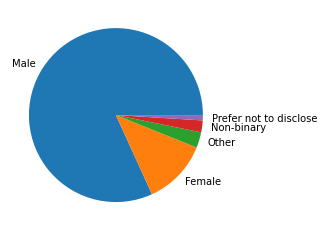

```python
# gender proportion - pie chart
pie_gender = df_survey['gender'].value_counts()
plt.pie(pie_gender, labels=pie_gender.index);
```

The vast majority of respondents (over 75%) identify as male. Female, prefer not to disclose, non-binary, and other comprise less than 25% collectively.

```python
# top 10 countries
def top(df, column):
    """
    INPUT:
        df - dataframe
        column - str; column

    OUTPUT:
        print statements
        df - dataframe
    """
    df_copy = df.copy()
    df_top = df_copy[column].value_counts()
    df_top10 = df_top.head(10)

    print(f"=== Top 10 {column} Respondents ===\n")

    print(df_top10)

    return df_top10
```

```
=== Top 10 country_origin Respondents ===

United States of America                                5907
Canada                                                   757
United Kingdom of Great Britain and Northern Ireland     717
Germany                                                  511
Australia                                                336
Poland                                                   301
Sweden                                                   293
Netherlands                                              274
India                                                    260
Brazil                                                   256
Name: country_origin, dtype: int64
```

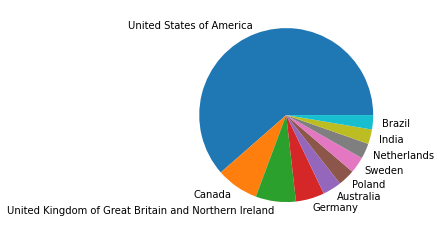

```python
df_top10 = top(df_survey, 'country_origin')

plt.pie(df_top10, labels=df_top10.index);
```

```
=== Top 10 country_residency Respondents ===

United States of America                                6343
Canada                                                   898
United Kingdom of Great Britain and Northern Ireland     860
Germany                                                  569
Australia                                                418
Sweden                                                   318
Netherlands                                              286
Poland                                                   259
Brazil                                                   231
Denmark                                                  145
Name: country_residency, dtype: int64
```

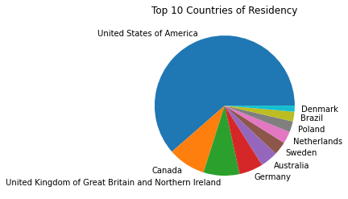

```python
df_top10 = top(df_survey, 'country_residency')

plt.pie(df_top10, labels=df_top10.index)
plt.title('Top 10 Countries of Residency');
```

The United States is where most of the respondents are from. The author of the survey is also US based. The next top 3 countries are also the same top countries of countries of origin (previous question). Indicating the most people are from the country that they are currently living in.

```
=== Top 10 us_state_residency Respondents ===

California       850
Texas            456
New York         433
Florida          351
Washington       283
Massachusetts    269
Illinois         268
Virginia         228
Pennsylvania     228
Ohio             214
Name: us_state_residency, dtype: int64
```

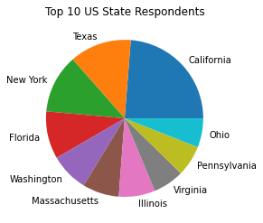

```python
# top 10 states (USA)
top_state = top(df_survey, 'us_state_residency')

# pie chart
plt.pie(top_state, labels=top_state.index)

plt.title('Top 10 US State Respondents');
```

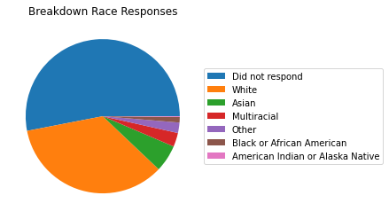

```python
# race distribution
race_graph = df_survey['race'].value_counts()
wedges = plt.pie(race_graph)

plt.legend(wedges, labels = race_graph.index, loc ='center left', bbox_to_anchor=(1, 0, 0.5, 1))
plt.title('Breakdown Race Responses');
```

```python
# remove 'Did not respond'
race_revised = df_survey.copy()
race_revised.drop(race_revised[(race_revised.race == 'Did not respond')].index, inplace=True)

race_revised['race'].value_counts()
```

```
White                               4713
Asian                                763
Multiracial                          394
Other                                295
Black or African American            157
American Indian or Alaska Native      21
Name: race, dtype: int64
```

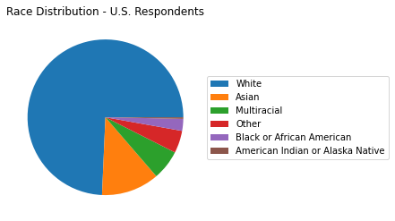

```python
# race distribution with 'Did not respond'
race_graph2 = race_revised['race'].value_counts()
wedges = plt.pie(race_graph2)
plt.legend(wedges, labels = race_graph2.index, loc ='center left', bbox_to_anchor=(1, 0, 0.5, 1))
plt.title('Race Distribution - U.S. Respondents');
```

Nearly 75% of respondents from the US identify as 'White' as seen above.

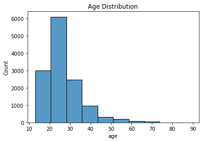

```python
# age - histogram
sns.histplot(data=df_survey, x="age", bins=10)

plt.title('Age Distribution');
```

### Kitchen Practices

```python
# heat map - often wash:  plates, thermometer, cutting board, utensils ... after handling meat

# construct df with `value_counts` for the different surfaces/items
all_counts = []
for item in ['often_different_plates', 'often_thermometer', 'often_not_wash_utensils', 'often_not_wash_cutting_board']:
    all_counts.append(df_survey[item].value_counts())

display(all_counts)
```

```
[Always                 10745
 Usually                 1790
 Sometimes                196
 About Half the time      185
 Seldom                   137
 Never                     96
 Name: often_different_plates, dtype: int64,
 Never                  4623
 Usually                2351
 Seldom                 1866
 Sometimes              1612
 About Half the time    1414
 Always                 1276
 Name: often_thermometer, dtype: int64,
 Never                  7604
 Seldom                 2631
 Sometimes              1068
 Usually                 719
 About Half the time     674
 Always                  439
 Name: often_not_wash_utensils, dtype: int64,
 Never                  10359
 Seldom                  1420
 Sometimes                424
 Always                   331
 Usually                  312
 About Half the time      292
 Name: often_not_wash_cutting_board, dtype: int64]
```

```python
items = pd.concat(all_counts, keys=['Use Different Plates', 'Use Thermometer', 'Not Wash Utensils', 'Not Wash Cutting Board'], axis=1)
items = items.fillna(0)
items
```

|  | Use Different Plates | Use Thermometer | Not Wash Utensils | Not Wash Cutting Board |
| --- | --- | --- | --- | --- |
| Always | 10745 | 1276 | 439 | 331 |
| Usually | 1790 | 2351 | 719 | 312 |
| Sometimes | 196 | 1612 | 1068 | 424 |
| About Half the time | 185 | 1414 | 674 | 292 |
| Seldom | 137 | 1866 | 2631 | 1420 |
| Never | 96 | 4623 | 7604 | 10359 |

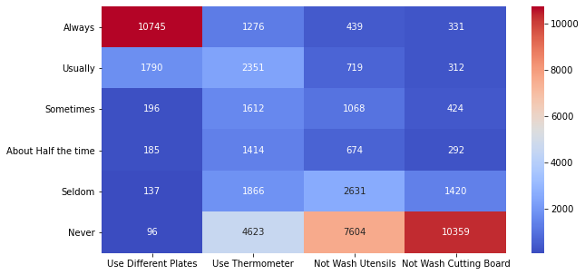

```python
f, ax = plt.subplots(figsize=(10,5))
sns.heatmap(items, annot=True, ax=ax, cmap="coolwarm", fmt="d");
```

The two responsese among the options displayed above that received the strongest response was that: (1) respondents ALWAYS use different plates when handeling raw and cooked meat in the kitchen and (2) respondents NEVER use the same cutting board without cleaning it with hot soapy water between using it for raw meat or chicken and using it for ready-to-eat food.

```python
# wash or not wash meats - bar chart

# construct df with `value_counts` washings of meats
meat_counts = []
for item2 in ['wash_pork', 'wash_poultry', 'wash_beef', 'wash_lamb_goat', 'wash_fish', 'wash_ground_meat', 'wash_other']:
    meat_counts.append(df_survey[item2].value_counts())

display(meat_counts)
```

```
[Dont Wash    10405
 Wash          1436
 Name: wash_pork, dtype: int64,
 Dont Wash    10347
 Wash          2705
 Name: wash_poultry, dtype: int64,
 Dont Wash    11312
 Wash          1348
 Name: wash_beef, dtype: int64,
 Dont Wash    8824
 Wash         1172
 Name: wash_lamb_goat, dtype: int64,
 Dont Wash    8703
 Wash         3549
 Name: wash_fish, dtype: int64,
 Dont Wash    12494
 Wash           272
 Name: wash_ground_meat, dtype: int64,
 Dont Wash    2608
 Wash          560
 Name: wash_other, dtype: int64]
```

```python
item2 = pd.concat(meat_counts, keys=['Pork', 'Poultry', 'Beef', 'Lamb or Goat', 'Fish', 'Ground meat', 'Other'], axis=1)
item2 = item2.fillna(0)
item2
```

|  | Pork | Poultry | Beef | Lamb or Goat | Fish | Ground meat | Other |
| --- | --- | --- | --- | --- | --- | --- | --- |
| Dont Wash | 10405 | 10347 | 11312 | 8824 | 8703 | 12494 | 2608 |
| Wash | 1436 | 2705 | 1348 | 1172 | 3549 | 272 | 560 |

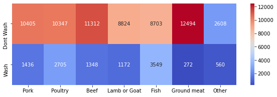

```python
f, ax = plt.subplots(figsize=(10,3))
sns.heatmap(item2, annot=True, ax=ax, fmt="d", cmap="coolwarm");
```

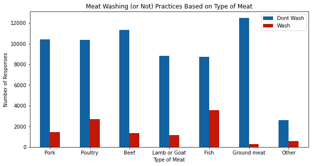

```python
item2.T.plot.bar(rot=0, figsize = (10,5), color=['#1261A0', '#C21807'])

# graph labels
plt.title('Meat Washing (or Not) Practices Based on Type of Meat')
plt.ylabel('Number of Responses')
plt.xlabel('Type of Meat');
```

It is promident that despite the type of meat more people do NOT wash compare to washing their meat. The most noticable difference is with ground meat. The category that has the smallest gap (comparatively) between wash and not wash is fish.

### Safety Practices

```python
# home safety vs. commercial kitchen
df_survey['visitor_home_safety'].value_counts()
```

```
4      3399
4.0    2189
5      2060
3      1795
5.0    1433
3.0    1135
2       575
2.0     353
1       146
1.0      91
Name: visitor_home_safety, dtype: int64
```

```python
df_survey['visitor_home_safety'] = df_survey['visitor_home_safety'].fillna(0).astype(int)
df_survey.loc[df_survey['visitor_home_safety'] == 0,'visitor_home_safety'] = np.nan
df_survey['visitor_home_safety'].value_counts()
```

```
4.0    5588
5.0    3493
3.0    2930
2.0     928
1.0     237
Name: visitor_home_safety, dtype: int64
```

```python
df_survey['commercial_safety'].value_counts()
```

```
5      5865
5.0    3759
4      1600
4.0    1097
3       363
3.0     237
2        93
2.0      75
1        54
1.0      33
Name: commercial_safety, dtype: int64
```

```python
df_survey['commercial_safety'] = df_survey['commercial_safety'].fillna(0).astype(int)
df_survey.loc[df_survey['commercial_safety'] == 0,'commercial_safety'] = np.nan
df_survey['commercial_safety'].value_counts()
```

```
5.0    9624
4.0    2697
3.0     600
2.0     168
1.0      87
Name: commercial_safety, dtype: int64
```

```python
# create copy of dataframe with necessary columns
safety_compare = df_survey.copy()
safety_compare = safety_compare[['commercial_safety','visitor_home_safety']]

safety_compare.head()
```

|  | commercial_safety | visitor_home_safety |
| --- | --- | --- |
| 0 | 2.0 | 1.0 |
| 1 | 5.0 | 5.0 |
| 2 | 5.0 | 4.0 |
| 3 | 5.0 | 4.0 |
| 4 | 4.0 | 2.0 |

```python
# check for NaN values
safety_compare.info()
```

```
<class 'pandas.core.frame.DataFrame'>
Int64Index: 13509 entries, 0 to 13526
Data columns (total 2 columns):
 #   Column               Non-Null Count  Dtype
---  ------               --------------  -----
 0   commercial_safety    13176 non-null  float64
 1   visitor_home_safety  13176 non-null  float64
dtypes: float64(2)
memory usage: 316.6 KB
```

```python
# drop rows with NaN in dataframe
safety_compare.dropna(inplace=True)

# verify rows have been dropped
safety_compare.info()
```

```
<class 'pandas.core.frame.DataFrame'>
Int64Index: 13176 entries, 0 to 13526
Data columns (total 2 columns):
 #   Column               Non-Null Count  Dtype
---  ------               --------------  -----
 0   commercial_safety    13176 non-null  float64
 1   visitor_home_safety  13176 non-null  float64
dtypes: float64(2)
memory usage: 308.8 KB
```

```python
# construct df with `value_counts` of individual columns
safety_counts = []
for item3 in ['commercial_safety', 'visitor_home_safety']:
    safety_counts.append(safety_compare[item3].value_counts())

safety_counts
```

```
[5.0    9624
 4.0    2697
 3.0     600
 2.0     168
 1.0      87
 Name: commercial_safety, dtype: int64,
 4.0    5588
 5.0    3493
 3.0    2930
 2.0     928
 1.0     237
 Name: visitor_home_safety, dtype: int64]
```

```python
item3 = pd.concat(safety_counts, keys=['Commercial Kitchen Safety', 'Home Kitchen Safety'], axis=1)
item3 = item3.fillna(0)
item3
```

|  | Commercial Kitchen Safety | Home Kitchen Safety |
| --- | --- | --- |
| 1.0 | 87 | 237 |
| 2.0 | 168 | 928 |
| 3.0 | 600 | 2930 |
| 4.0 | 2697 | 5588 |
| 5.0 | 9624 | 3493 |

```python
# reverse the sequence of rows
item3_reverse = item3[::-1]

# confirm change
item3_reverse
```

|  | Commercial Kitchen Safety | Home Kitchen Safety |
| --- | --- | --- |
| 5.0 | 9624 | 3493 |
| 4.0 | 2697 | 5588 |
| 3.0 | 600 | 2930 |
| 2.0 | 168 | 928 |
| 1.0 | 87 | 237 |

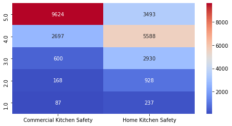

```python
f, ax = plt.subplots(figsize=(8,4))
sns.heatmap(item3_reverse, annot=True, ax=ax, fmt="d", cmap="coolwarm");
```

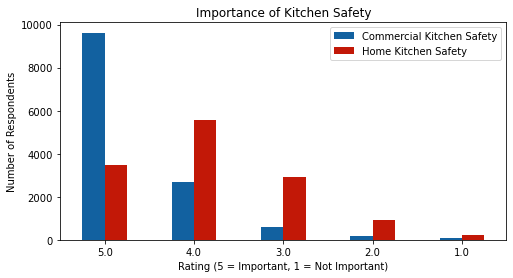

```python
item3_reverse.plot.bar(figsize=(8,4), rot=0, color=['#1261A0', '#C21807'])
plt.title('Importance of Kitchen Safety')
plt.xlabel('Rating (5 = Important, 1 = Not Important)')
plt.ylabel('Number of Respondents');
```

### Correlation between Commercial and Home Kichten Safety

```python
# distribute commericial_safety answers to inidivdual columns
commercial_safety_groups = pd.get_dummies(safety_compare['commercial_safety'])
safety_compare[['CS1', 'CS2', 'CS3','CS4','CS5']] = commercial_safety_groups
safety_compare.head(10)
```

|  | commercial_safety | visitor_home_safety | CS1 | CS2 | CS3 | CS4 | CS5 |
| --- | --- | --- | --- | --- | --- | --- | --- |
| 0 | 2.0 | 1.0 | 0 | 1 | 0 | 0 | 0 |
| 1 | 5.0 | 5.0 | 0 | 0 | 0 | 0 | 1 |
| 2 | 5.0 | 4.0 | 0 | 0 | 0 | 0 | 1 |
| 3 | 5.0 | 4.0 | 0 | 0 | 0 | 0 | 1 |
| 4 | 4.0 | 2.0 | 0 | 0 | 0 | 1 | 0 |
| 5 | 5.0 | 5.0 | 0 | 0 | 0 | 0 | 1 |
| 6 | 3.0 | 2.0 | 0 | 0 | 1 | 0 | 0 |
| 7 | 5.0 | 4.0 | 0 | 0 | 0 | 0 | 1 |
| 8 | 4.0 | 3.0 | 0 | 0 | 0 | 1 | 0 |
| 9 | 5.0 | 3.0 | 0 | 0 | 0 | 0 | 1 |

```python
# created visitor_home_safety dummies
visitor_home_safety_groups = pd.get_dummies(safety_compare['visitor_home_safety'])
safety_compare[['VHS1', 'VHS2', 'VHS3','VHS4','VHS5']] = visitor_home_safety_groups
safety_compare.head(10)
```

|  | commercial_safety | visitor_home_safety | CS1 | CS2 | CS3 | CS4 | CS5 | VHS1 | VHS2 | VHS3 | VHS4 | VHS5 |
| --- | --- | --- | --- | --- | --- | --- | --- | --- | --- | --- | --- | --- |
| 0 | 2.0 | 1.0 | 0 | 1 | 0 | 0 | 0 | 1 | 0 | 0 | 0 | 0 |
| 1 | 5.0 | 5.0 | 0 | 0 | 0 | 0 | 1 | 0 | 0 | 0 | 0 | 1 |
| 2 | 5.0 | 4.0 | 0 | 0 | 0 | 0 | 1 | 0 | 0 | 0 | 1 | 0 |
| 3 | 5.0 | 4.0 | 0 | 0 | 0 | 0 | 1 | 0 | 0 | 0 | 1 | 0 |
| 4 | 4.0 | 2.0 | 0 | 0 | 0 | 1 | 0 | 0 | 1 | 0 | 0 | 0 |
| 5 | 5.0 | 5.0 | 0 | 0 | 0 | 0 | 1 | 0 | 0 | 0 | 0 | 1 |
| 6 | 3.0 | 2.0 | 0 | 0 | 1 | 0 | 0 | 0 | 1 | 0 | 0 | 0 |
| 7 | 5.0 | 4.0 | 0 | 0 | 0 | 0 | 1 | 0 | 0 | 0 | 1 | 0 |
| 8 | 4.0 | 3.0 | 0 | 0 | 0 | 1 | 0 | 0 | 0 | 1 | 0 | 0 |
| 9 | 5.0 | 3.0 | 0 | 0 | 0 | 0 | 1 | 0 | 0 | 1 | 0 | 0 |

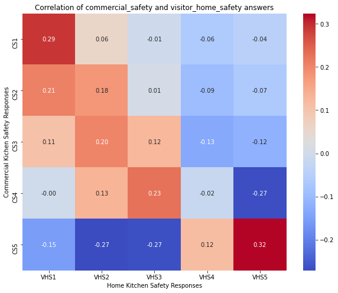

```python
# calculated correlations and created heatmap
corr_matrix = safety_compare.corr(method='spearman')
pivot = corr_matrix[2:7][['VHS1', 'VHS2', 'VHS3','VHS4','VHS5']]
plt.figure(figsize=(10,8));
sns.heatmap(pivot, cmap='coolwarm', annot=True, fmt='.2f');
plt.title("Correlation of commercial_safety and visitor_home_safety answers")

plt.ylabel('Commercial Kichen Safety Responses')
plt.xlabel('Home Kitchen Safety Responses');
```

The correlations between respondents rating safety as a top priority (or low) for both commericial kitchens or as a vistor in a home kitchen is the strongest -- seens by the darkest red-shade on opposite corners of the heatmap.

## Safety Ratings by Age Groups

```python
# safety compare with age
safety_compare_age = df_survey.copy()
safety_compare_age = safety_compare_age[['age','commercial_safety','visitor_home_safety']]
safety_compare_age.head()
```

|  | age | commercial_safety | visitor_home_safety |
| --- | --- | --- | --- |
| 0 | 22.0 | 2.0 | 1.0 |
| 1 | 49.0 | 5.0 | 5.0 |
| 2 | 32.0 | 5.0 | 4.0 |
| 3 | 30.0 | 5.0 | 4.0 |
| 4 | 20.0 | 4.0 | 2.0 |

```python
# drop rows with NaN in dataframe
safety_compare_age.dropna(inplace=True)
```

```python
# melt df
df2 = pd.melt(safety_compare_age, id_vars=['age'], value_vars=['commercial_safety', 'visitor_home_safety'])
```

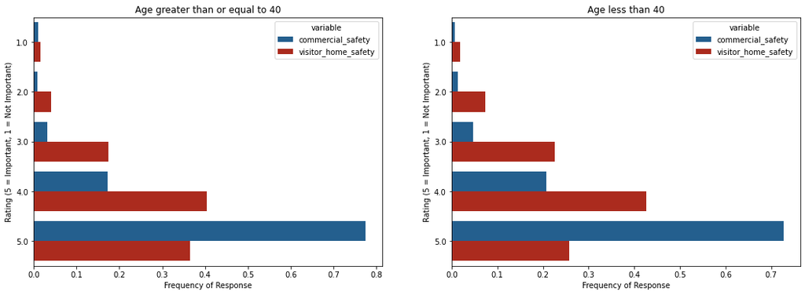

```python
# create visualizations
df2['value'] = df2['value'].astype('category')
df_less_40 = df2[df2['age']<40].copy()
df_less_40['rate'] = 2/len(df_less_40)
df_more_40 = df2[df2['age']>=40].copy()
df_more_40['rate'] = 2/len(df_more_40)

# array with the colors
colors = ['#1261A0', '#C21807']

# Set custom color palette
customPalette = sns.set_palette(sns.color_palette(colors))

plt.figure(figsize=(18,6))
plt.subplot(1, 2, 1) # 1 row, 2 cols, subplot 1
sns.barplot(x="rate", y="value", hue='variable', data=df_more_40, estimator=sum, palette=customPalette);
plt.title('Age greater than or equal to 40')
plt.ylabel('Rating (5 = Important, 1 = Not Important)')
plt.xlabel('Frequency of Response');

plt.subplot(1, 2, 2) # 1 row, 2 cols, subplot 2
sns.barplot(x="rate", y="value", hue='variable', data=df_less_40, estimator=sum);
plt.title('Age less than 40')
plt.ylabel('Rating (5 = Important, 1 = Not Important)')
plt.xlabel('Frequency of Response');
```

The frequency of responses when the two age groups are created and compared do not show any major observable difference in how respondents that are "younger" and "older" respond to this question. The pattern of the bars above are relatively the same.

```python
# overall safety by age
overall_safety_age = df_survey.copy()
overall_safety_age = overall_safety_age[['age','importance_food_safety_cooking']]
overall_safety_age.head()
```

|  | age | importance_food_safety_cooking |
| --- | --- | --- |
| 0 | 22.0 | 3 |
| 1 | 49.0 | 2 |
| 2 | 32.0 | 4 |
| 3 | 30.0 | 4 |
| 4 | 20.0 | 5 |

```python
# drop any NaN values
overall_safety_age.dropna(inplace=True)

# check data type
overall_safety_age['importance_food_safety_cooking'].dtype
```

```
dtype('O')
```

```python
# convert 'importance_food_safety_cooking' to int
overall_safety_age['importance_food_safety_cooking'] = overall_safety_age['importance_food_safety_cooking'].astype(int)
```

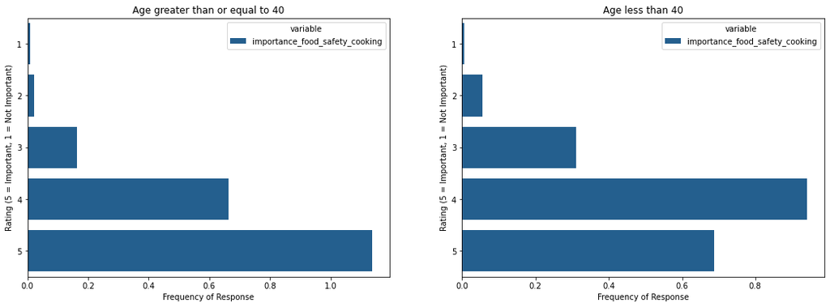

```python
# drop rows with NaN in dataframe
overall_safety_age.dropna(inplace=True)

# melt df
df3 = pd.melt(overall_safety_age, id_vars=['age'], value_vars=['importance_food_safety_cooking'])

# create visualizations
df3['value'] = df3['value'].astype('category')
df_less_40 = df3[df3['age']<40].copy()
df_less_40['rate'] = 2/len(df_less_40)
df_more_40 = df3[df3['age']>=40].copy()
df_more_40['rate'] = 2/len(df_more_40)

# array with the colors
colors = ['#1261A0', '#C21807']

# Set custom color palette
customPalette = sns.set_palette(sns.color_palette(colors))

plt.figure(figsize=(18,6))
plt.subplot(1, 2, 1) # 1 row, 2 cols, subplot 1
sns.barplot(x="rate", y="value", hue='variable', data=df_more_40, estimator=sum, palette=customPalette);
plt.title('Age greater than or equal to 40')
plt.ylabel('Rating (5 = Important, 1 = Not Important)')
plt.xlabel('Frequency of Response');

plt.subplot(1, 2, 2) # 1 row, 2 cols, subplot 2
sns.barplot(x="rate", y="value", hue='variable', data=df_less_40, estimator=sum);
plt.title('Age less than 40')
plt.ylabel('Rating (5 = Important, 1 = Not Important)')
plt.xlabel('Frequency of Response');
```

There is a difference between the two age groups. Those less than 40 years old, the top response was a 4. Meanwhile those 40 years old or older find a greater importance to food safety when cooking with the top response as a 5. There was a noticable difference visually comparing the two groups.